# Recap general linear model

Author

Affiliation

Lieven Clement

Ghent University

# 1 Breast cancer example

- part of study https://doi.org/10.1093/jnci/djj052)
- Histologic grade in breast cancer clinically prognostic. Association of histologic grade on expression of KPNA2 gene that is known to be associated with poor BC prognosis.
- Population: all current and future breast cancer patients

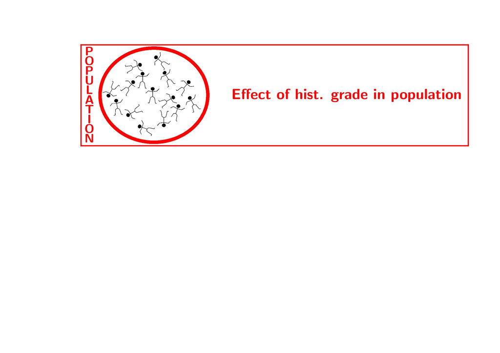

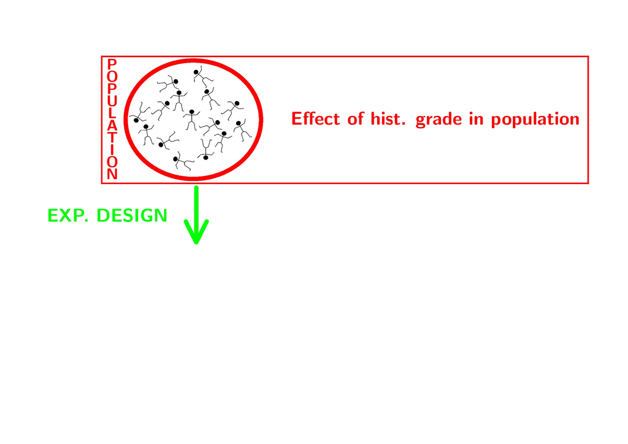

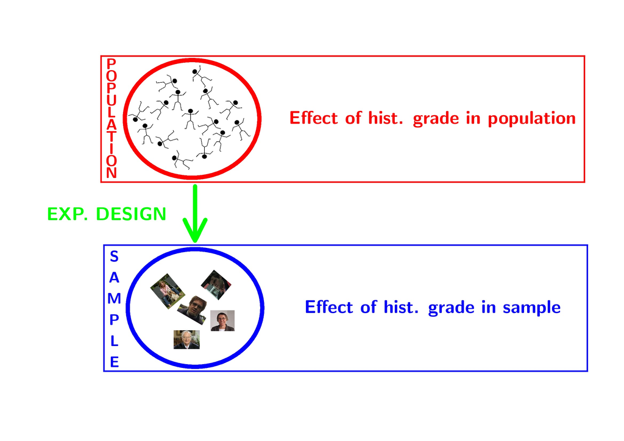

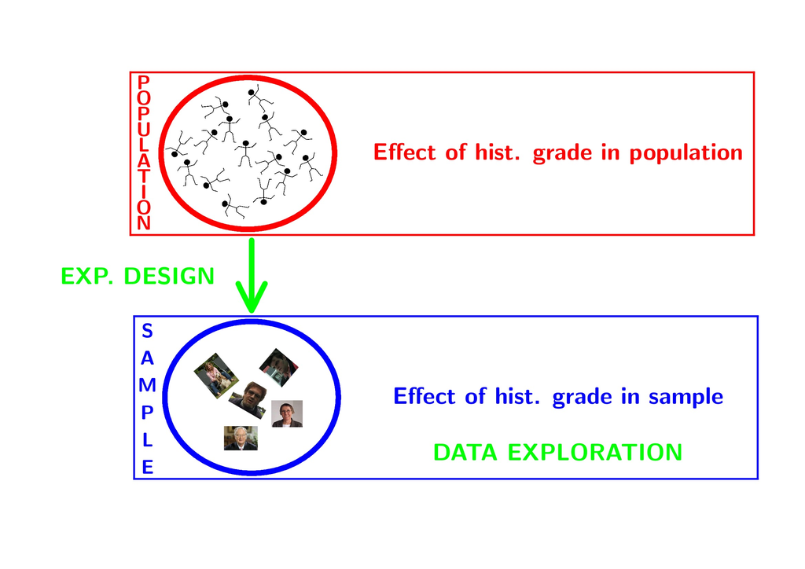

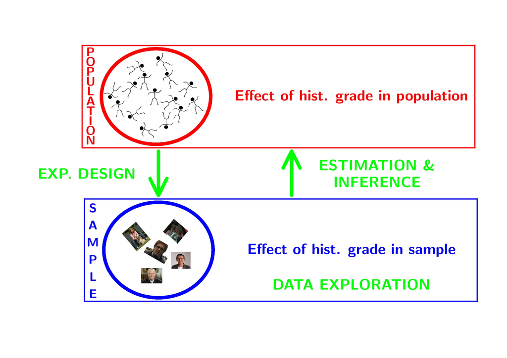

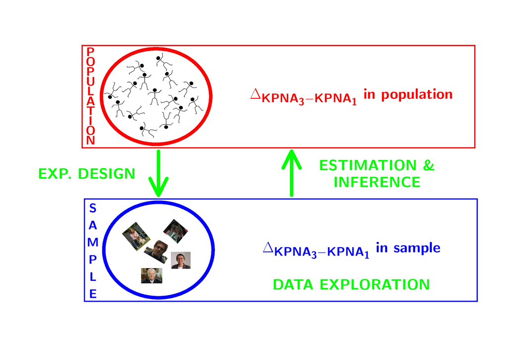

# 2 Data Exploration

## 2.1 Import

```r
library(tidyverse)
gene <- read.table("https://raw.githubusercontent.com/statOmics/SGA21/master/data/kpna2.txt",header=TRUE)
head(gene)
```

```
  grade node     gene
1     3    1 367.8179
2     3    1 590.3576
3     1    1 346.6583
4     1    1 258.4455
5     1    0 153.8416
6     3    0 643.6799
```

We will transform the variable grade and node to a factor

```r
gene$grade <- as.factor(gene$grade)
gene$node <- as.factor(gene$node)
```

## 2.2 Summary statistics

```r
geneSum <- gene |>
  group_by(grade) |>
  summarize(mean = mean(gene),
            sd = sd(gene),
            n=length(gene)
            ) |>
  mutate(se = sd/sqrt(n))
geneSum
```

```
# A tibble: 2 × 5
  grade  mean    sd     n    se
  <fct> <dbl> <dbl> <int> <dbl>
1 1      233.  65.5    12  18.9
2 3      561. 144.     12  41.4
```

## 2.3 Visualisation

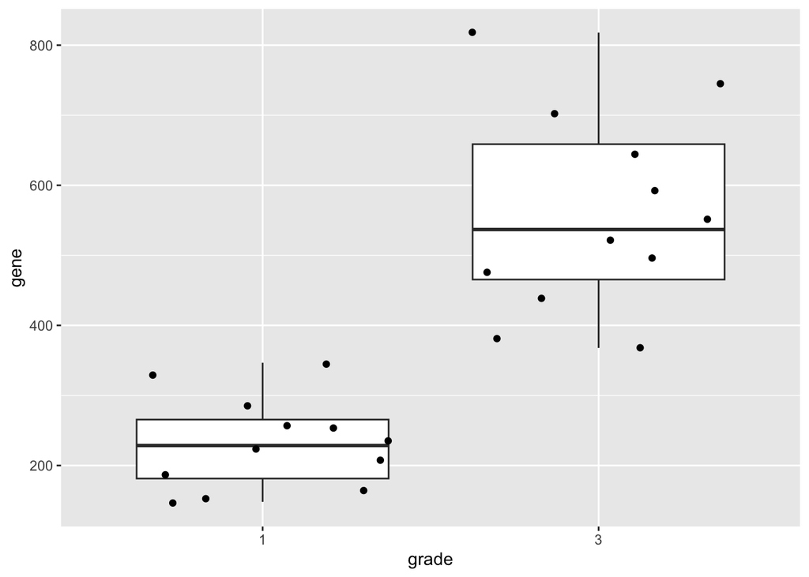

```r
gene |>
  ggplot(aes(x=grade,y=gene)) +
  geom_boxplot(outlier.shape=NA) +
  geom_jitter()
```

We can also save the plots as objects for later use!

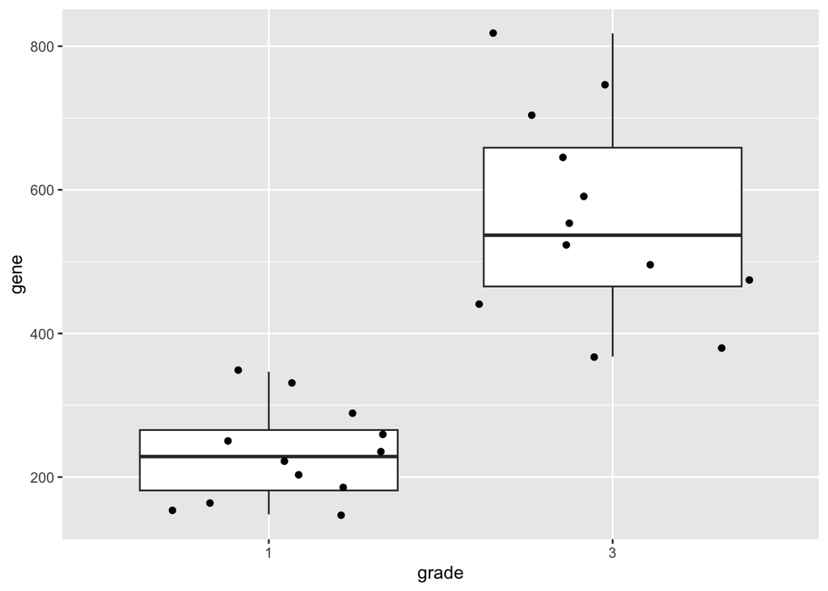

```r
p1 <- gene |>
  ggplot(aes(x=grade,y=gene)) +
  geom_boxplot(outlier.shape=NA) +
  geom_jitter()

p2 <- gene |>
  ggplot(aes(sample=gene)) +
  geom_qq() +
  geom_qq_line() +
  facet_wrap(~grade)

p1
```

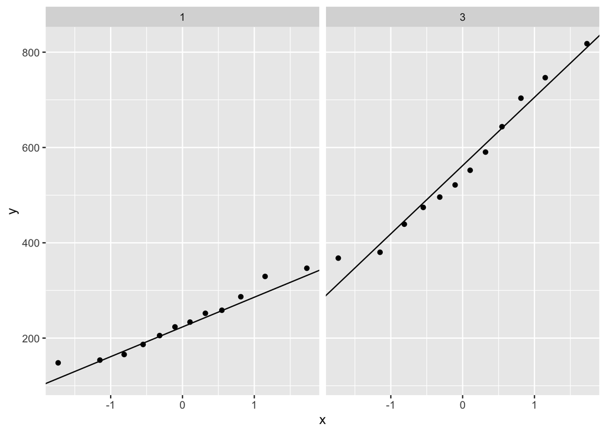

```r
p2
```

## 2.4 Research questions

Researchers want to assess the association of the histological grade on KPNA2 gene expression

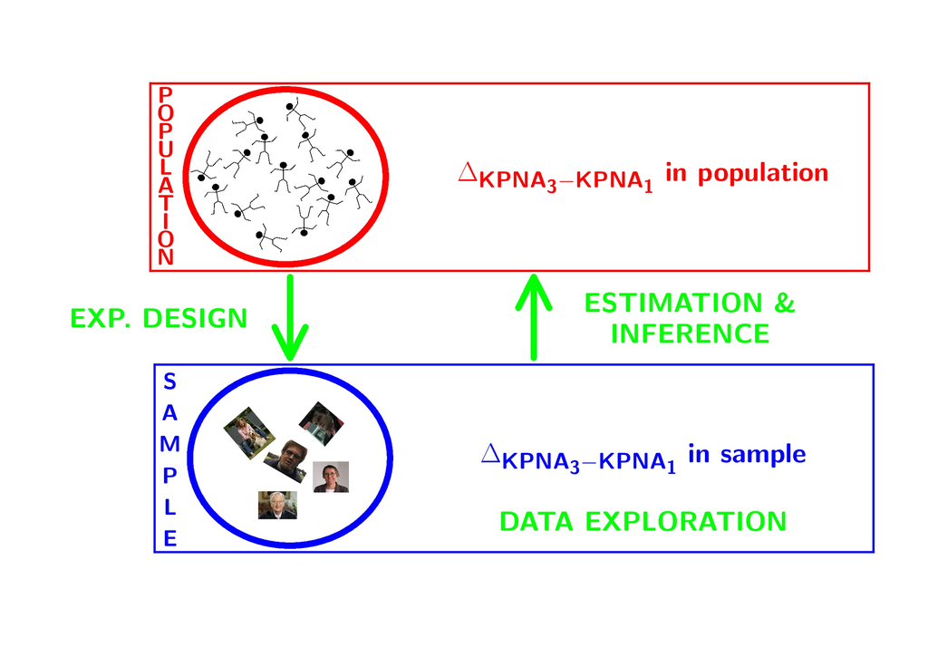

## 2.5 Estimation of effect size and standard error

```r
effectSize <- tibble(
  delta = geneSum$mean[2]- geneSum$mean[1],
  seDelta = sqrt(sum(geneSum$se^2))
  )
effectSize
```

```
# A tibble: 1 × 2
  delta seDelta
  <dbl>   <dbl>
1  329.    45.5
```

# 3 Statistical Inference

- Researchers want to assess the association of histological grade on KPNA2 gene expression
- Inference?

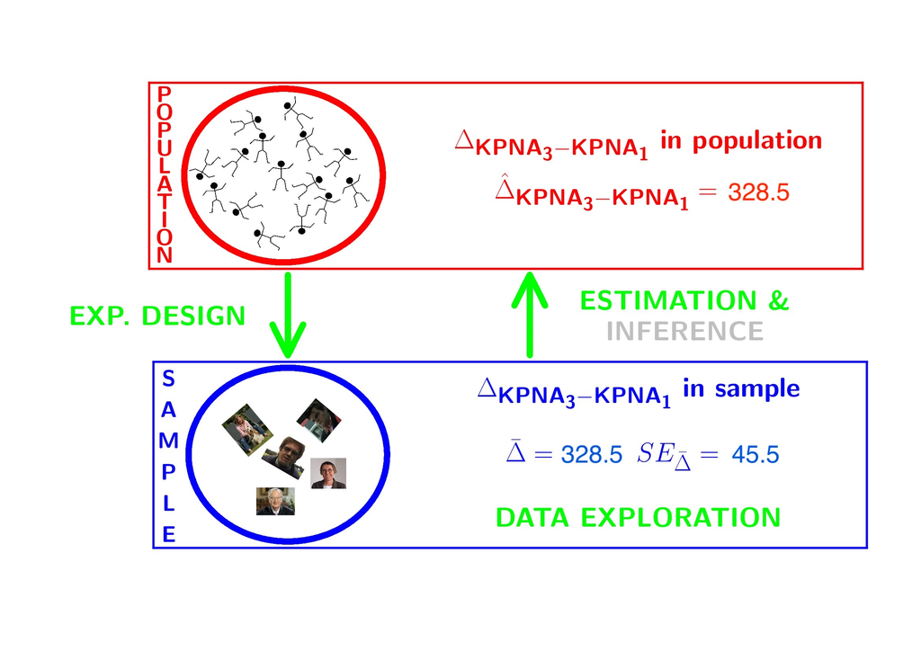

- Researchers want to assess the association of histological grade on KPNA2 gene expression
- Inference?
- testing + CI $ $ Assumptions
- In general we start from **alternative hypothesis** $H_A$: we want to show an association
- Gene expression of grade 1 and grade 3 patients is on average different
- But, we will assess it by falsifying the opposite:
- The average KPNA2 gene expression of grade 1 and grade 3 patients is equal
- How likely is it to observe an equal or more extreme association than the one observed in the sample when the null hypothesis is true?
- When we make assumptions about the distribution of our test statistic we can quantify this probability: **p-value**.
- If the p-value is below a significance threshold $\alpha$ we reject the null hypothesis

*We control the probability of a false positive result at the $\alpha$-level (type I error)*

- The p-value will only be calculated correctly if the underlying assumptions hold!

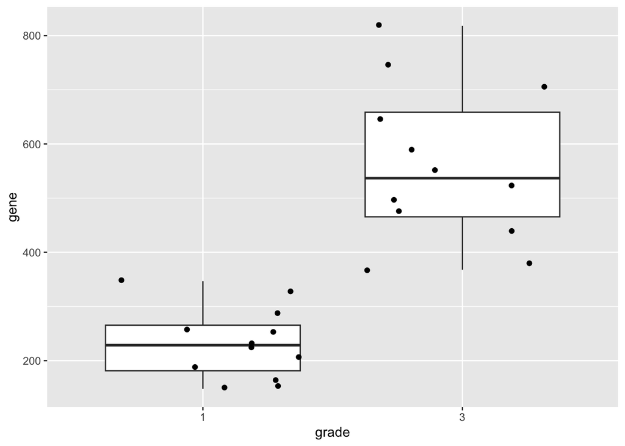

```r
library(gridExtra)
p1
```

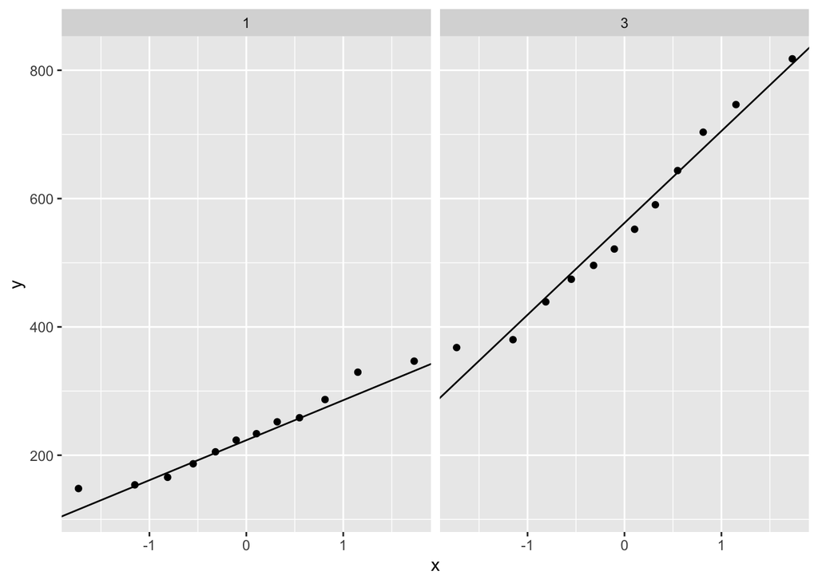

```r
p2
```

```r
t.test(gene~grade,data=gene)
```

```
    Welch Two Sample t-test

data:  gene by grade
t = -7.2132, df = 15.384, p-value = 2.598e-06
alternative hypothesis: true difference in means between group 1 and group 3 is not equal to 0
95 percent confidence interval:
 -425.4218 -231.6751
sample estimates:
mean in group 1 mean in group 3
       232.5003        561.0487
```

```r
effectSize <- effectSize |>
  mutate(t.stat=delta/seDelta) |>
  mutate(p.value= pt(-abs(t.stat),21.352)*2)

effectSize
```

```
# A tibble: 1 × 4
  delta seDelta t.stat     p.value
  <dbl>   <dbl>  <dbl>       <dbl>
1  329.    45.5   7.21 0.000000376
```

- Intensities are often not normally distributed and have a mean variance relation
- Commonly log2-transformed
- Differences on log scale:

$$\log_2(B) - \log_2(A) = \log_2 \frac{B}{A} = \log_2 FC_{\frac{B}{A}}$$

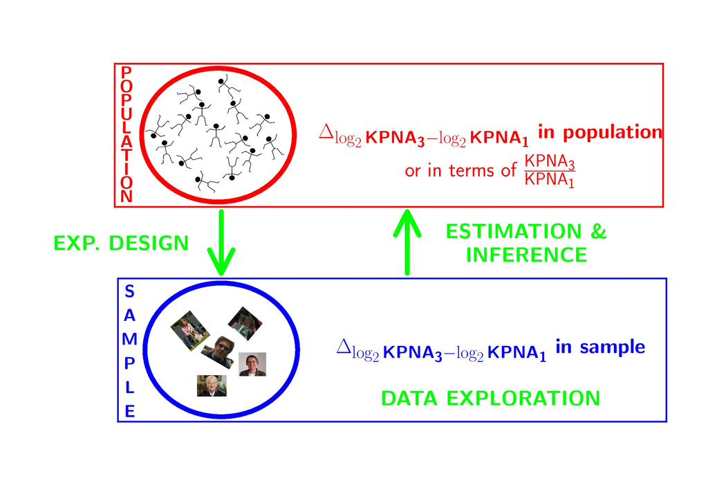

## 3.1 Log transformation

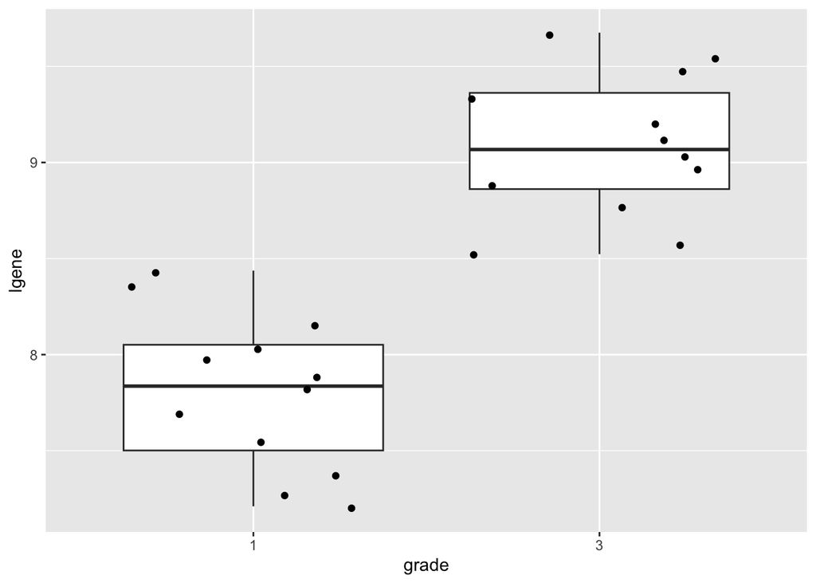

```r
gene <- gene |>
  mutate(lgene = log2(gene))

p1 <- gene |>
  ggplot(aes(x=grade,y=lgene)) +
  geom_boxplot(outlier.shape=NA) +
  geom_jitter()

p2 <- gene |>
  ggplot(aes(sample=lgene)) +
  geom_qq() +
  geom_qq_line() +
  facet_wrap(~grade)

p1
```

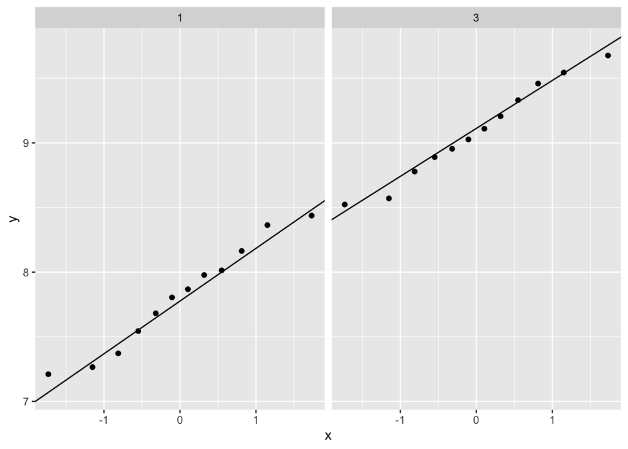

```r
p2
```

```r
logtest <- t.test(lgene~grade,data=gene,var.equal=TRUE)
logtest
```

```
    Two Sample t-test

data:  lgene by grade
t = -8.0455, df = 22, p-value = 5.372e-08
alternative hypothesis: true difference in means between group 1 and group 3 is not equal to 0
95 percent confidence interval:
 -1.610148 -0.950178
sample estimates:
mean in group 1 mean in group 3
       7.808478        9.088641
```

```r
log2FC <- logtest$estimate[2]-logtest$estimate[1]
log2FC
```

```
mean in group 3
       1.280163
```

```r
names(log2FC) <- "g3-g1"
2^log2FC
```

```
   g3-g1
2.428664
```

## 3.2 Conclusion

There is an extremely significant association of the histological grade on the gene expression in tumor tissue. On average, the gene expression for the grade 3 patients is 2.43 times higher than the gene expression in grade 1 patients (95% CI [1.93, 3.05], $p<<0.001$).

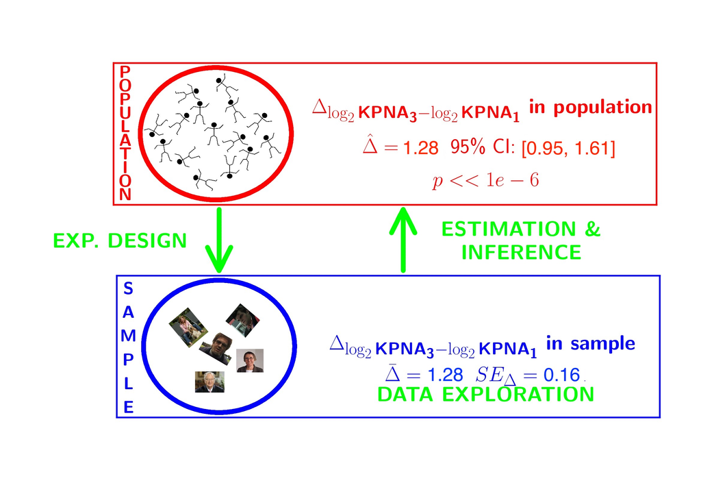

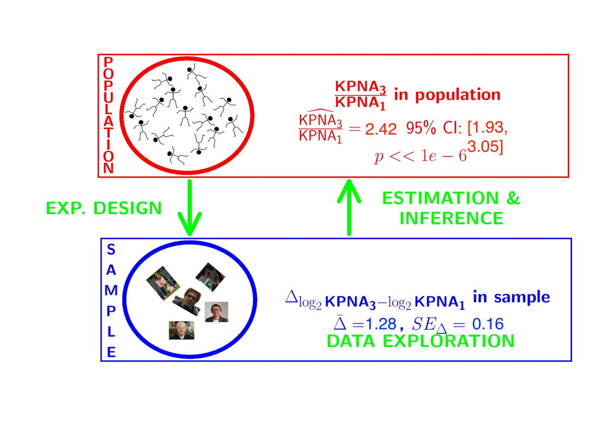

The patients also differ in their lymph node status. Hence, we have a two factorial design: grade x lymph node status!!!

Solution??

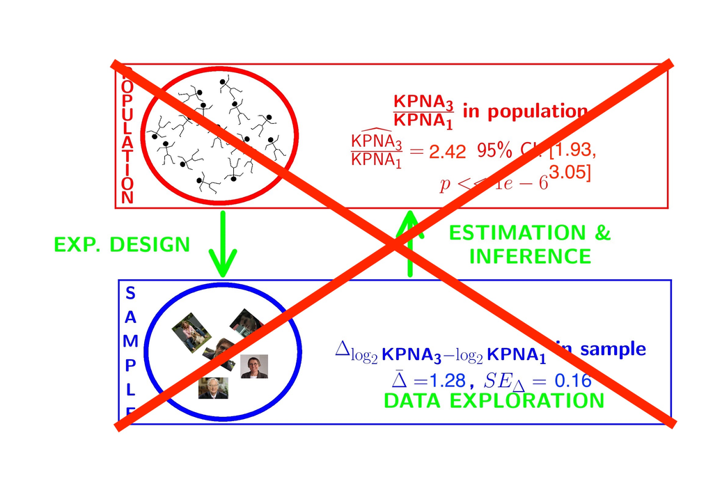

# 4 General Linear Model

How can we integrate multiple factors and continuous covariates in a linear model.

$$y_i= \beta_0 + \beta_1 x_{i,1} + \beta_2 x_{i,2} + \beta_{12}x_{i,1}x_{i,2}+\epsilon_i,$$
with

- $x_{i,1}$ a dummy variable for histological grade: $x_{i,1}=\begin{cases} 0& \text{grade 1}\\ 1& \text{grade 3} \end{cases}$
- $x_{i,2}$ a dummy variable for lymph node status: $x_{i,2}=\begin{cases} 0& \text{lymph nodes were not removed}\\ 1& \text{lymph nodes were removed} \end{cases}$
- $\epsilon_i$?

## 4.1 Implementation in R

```r
lm1 <- lm(gene~grade*node,data=gene)
summary(lm1)
```

```
Call:
lm(formula = gene ~ grade * node, data = gene)

Residuals:
     Min       1Q   Median       3Q      Max
-201.748  -53.294   -6.308   46.216  277.601

Coefficients:
             Estimate Std. Error t value Pr(>|t|)
(Intercept)    180.51      44.37   4.068   0.0006 ***
grade3         401.33      62.75   6.396 3.07e-06 ***
node1          103.98      62.75   1.657   0.1131
grade3:node1  -145.57      88.74  -1.640   0.1166
---
Signif. codes:  0 '***' 0.001 '**' 0.01 '*' 0.05 '.' 0.1 ' ' 1

Residual standard error: 108.7 on 20 degrees of freedom
Multiple R-squared:  0.7437,    Adjusted R-squared:  0.7052
F-statistic: 19.34 on 3 and 20 DF,  p-value: 3.971e-06
```

## 4.2 Assumptions

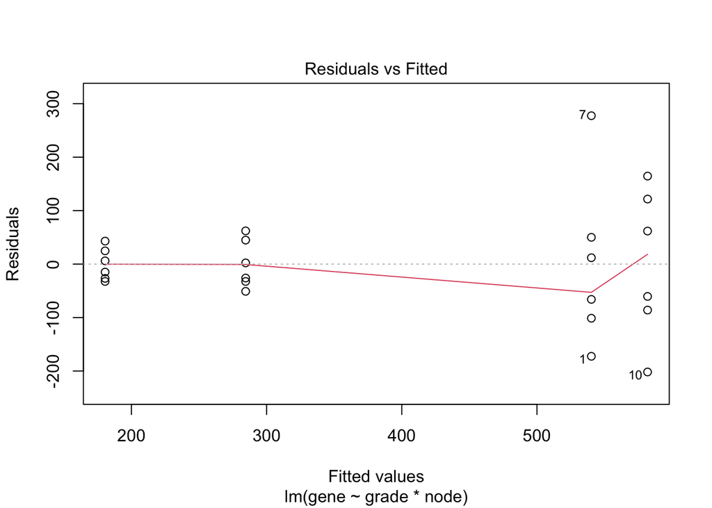

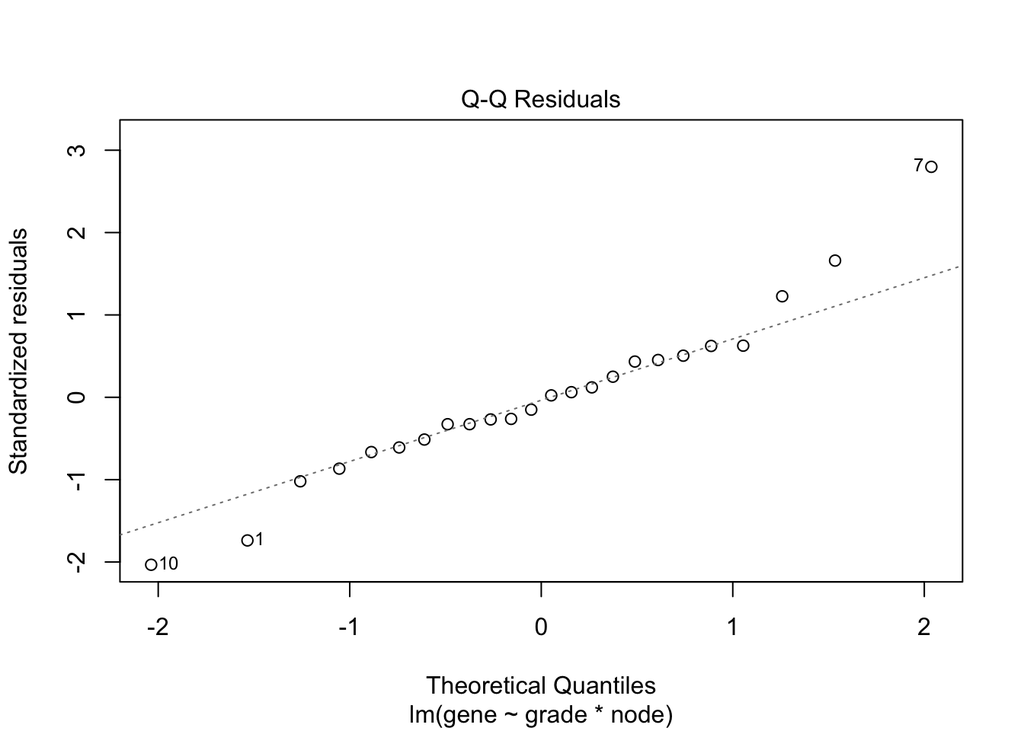

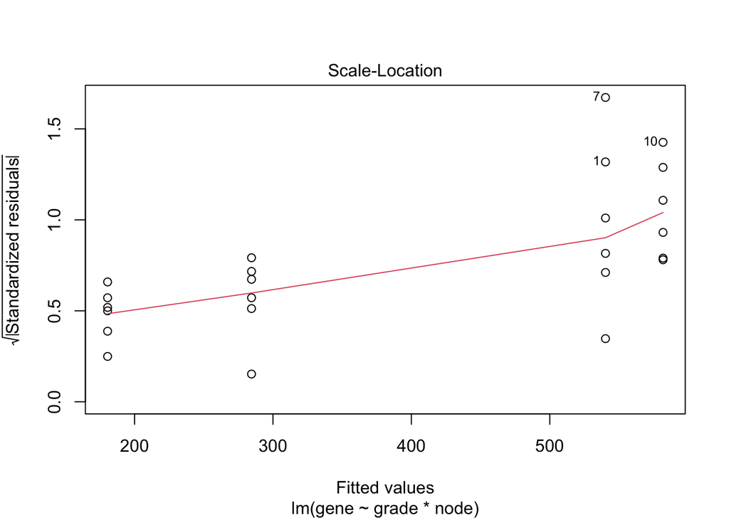

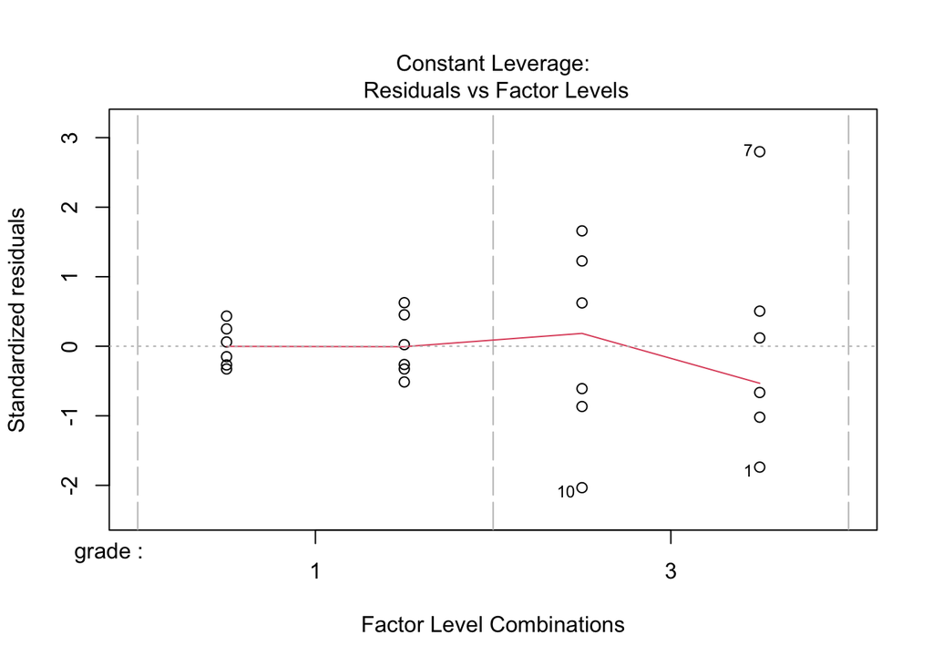

```r
plot(lm1)
```

## 4.3 Breast cancer example

- Paper: https://doi.org/10.1093/jnci/djj052
- Histologic grade in breast cancer provides clinically important prognostic information. Two factors have to be considered: Histologic grade (grade 1 and grade 3) and lymph node status (0 vs 1). The researchers assessed gene expression of the KPNA2 gene a protein-coding gene associated with breast cancer and are mainly interested in the association of histological grade. Note, that the gene variable consists of background corrected normalized intensities obtained with a microarray platform. Upon log-transformation, they are known to be a good proxy for the $\log$ transformed concentration of gene expression product of the KPNA2 gene.
- Research questions and translate them towards model parameters (contrasts)?
- Make an R markdown file to answer the research questions

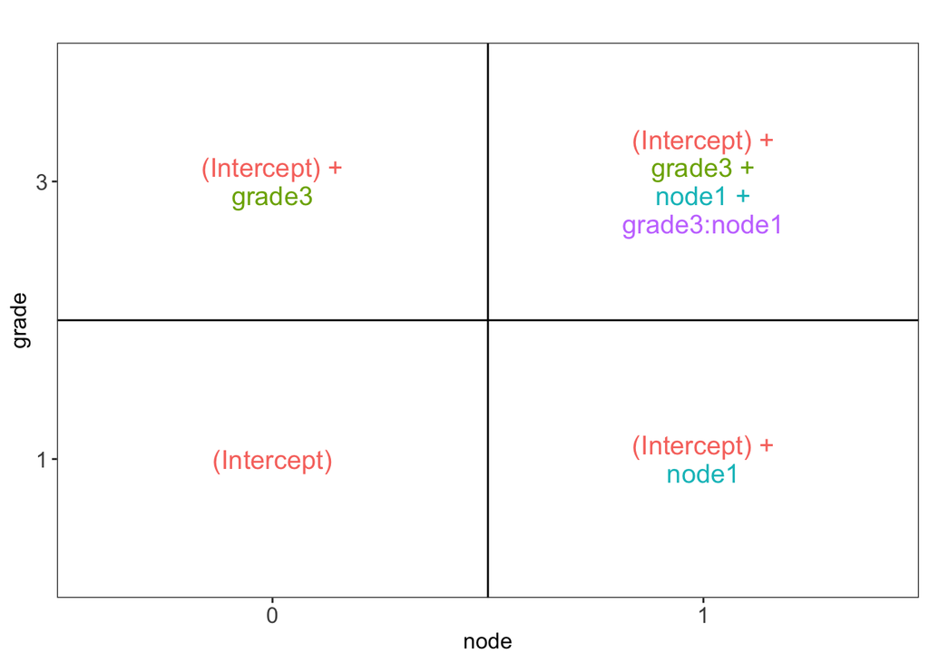

```r
library(ExploreModelMatrix)
explMx <- VisualizeDesign(gene,designFormula = ~grade*node)
explMx$plotlist
```

You can also explore the model matrix interactively:

```r
ExploreModelMatrix(gene,designFormula = ~grade*node)
```

# 5 Linear regression in matrix form

## 5.1 Scalar form

- Consider a vector of predictors $\mathbf{x}=(x_1,\ldots,x_p)^T$ and
- a real-valued response $Y$
- then the linear regression model can be written as
  $$Y=f(\mathbf{x}) +\epsilon=\beta_0+\sum\limits_{j=1}^p x_j\beta_j + \epsilon$$
  with i.i.d. $\epsilon\sim N(0,\sigma^2)$

## 5.2 Matrix form

- $n$ observations $(\mathbf{x}_1,y_1) \ldots (\mathbf{x}_n,y_n)$
- Regression in matrix notation
  $$\mathbf{Y}=\mathbf{X\beta} + \mathbf{\epsilon}$$
  with $\mathbf{Y}=\left[\begin{array}{c}y_1\\ \vdots\\y_n\end{array}\right]$, $\mathbf{X}=\left[\begin{array}{cccc} 1&x_{11}&\ldots&x_{1p}\\ \vdots&\vdots&&\vdots\\ 1&x_{n1}&\ldots&x_{np} \end{array}\right]$, $\mathbf{\beta}=\left[\begin{array}{c}\beta_0\\ \vdots\\ \beta_p\end{array}\right]$ and $\mathbf{\epsilon}=\left[\begin{array}{c} \epsilon_1 \\ \vdots \\ \epsilon_n\end{array}\right]$

## 5.3 Least Squares (LS)

- Minimize the residual sum of squares
  $$\begin{eqnarray*}
  RSS(\mathbf{\beta})&=&\sum\limits_{i=1}^n e^2_i\\
  &=&\sum\limits_{i=1}^n \left(y_i-\beta_0-\sum\limits_{j=1}^p x_{ij}\beta_j\right)^2
  \end{eqnarray*}$$
- or in matrix notation
  $$\begin{eqnarray*}
  RSS(\mathbf{\beta})&=&(\mathbf{Y}-\mathbf{X\beta})^T(\mathbf{Y}-\mathbf{X\beta})\\
  &=&\Vert \mathbf{Y}-\mathbf{X\beta}\Vert^2_2
  \end{eqnarray*}$$
  with the $L_2$-norm of a $p$-dim. vector $v$ $\Vert \mathbf{v} \Vert=\sqrt{v_1^2+\ldots+v_p^2}$ $\rightarrow$ $\hat{\mathbf{\beta}}=\text{argmin}_\beta \Vert \mathbf{Y}-\mathbf{X\beta}\Vert^2_2$

### 5.3.1 Minimize RSS

$$\begin{array}{ccc}
\frac{\partial RSS}{\partial \mathbf{\beta}}&=&\mathbf{0}\\\\
\frac{(\mathbf{Y}-\mathbf{X\beta})^T(\mathbf{Y}-\mathbf{X\beta})}{\partial \mathbf{\beta}}&=&\mathbf{0}\\\\
-2\mathbf{X}^T(\mathbf{Y}-\mathbf{X\beta})&=&\mathbf{0}\\\\
\mathbf{X}^T\mathbf{X\beta}&=&\mathbf{X}^T\mathbf{Y}\\\\
\hat{\mathbf{\beta}}&=&(\mathbf{X}^T\mathbf{X})^{-1}\mathbf{X}^T\mathbf{Y}
\end{array}$$

### 5.3.2 Geometric Interpretation

#### Toy dataset

We will illustrate this on a toy dataset

```r
library(tidyverse)
data <- data.frame(x=1:3,y=c(1,2,2))
data
```

```
  x y
1 1 1
2 2 2
3 3 2
```

#### Matrix form for toy dataset

We can also write this in matrix form

$$\mathbf{Y} = \mathbf{X}\boldsymbol{\beta}+\boldsymbol{\epsilon}$$

with

$$\mathbf{Y}=\left[
\begin{array}{c}
1\\
2\\
2\\
\end{array}\right],
\quad
\mathbf{X}= \left[
\begin{array}{cc}
1&1\\
1&2\\
1&3\\
\end{array}
\right],
\quad \boldsymbol{\beta} = \left[
\begin{array}{c}
\beta_0\\
\beta_1\\
\end{array}
\right]
\quad
\text{and}
\quad
\boldsymbol{\epsilon}=
\left[
\begin{array}{c}
\epsilon_1\\
\epsilon_2\\
\epsilon_3
\end{array}
\right]$$

#### Classical interpretation

Model fit and predictions based on the toy dataset

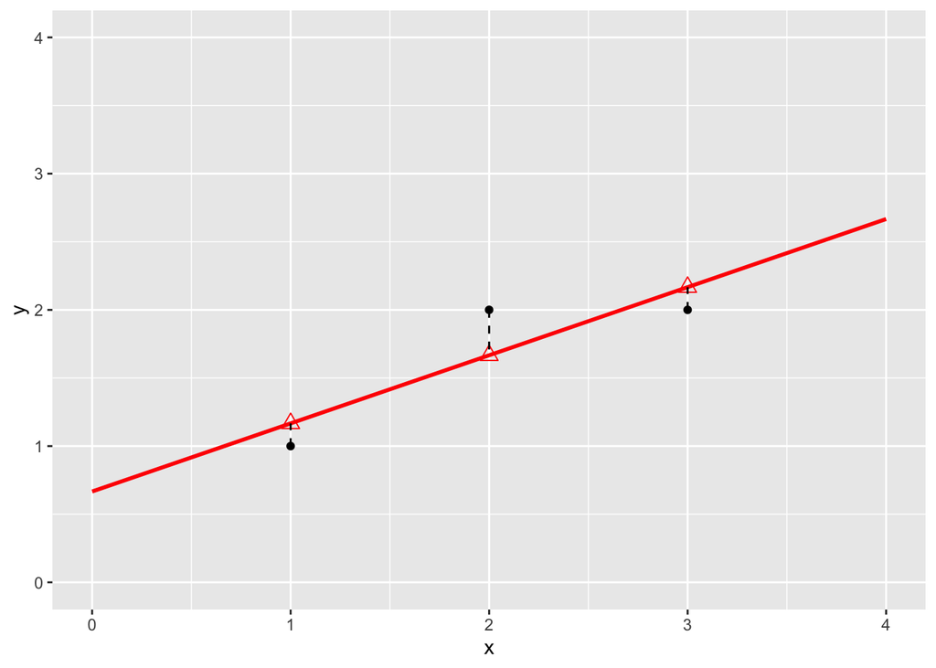

```r
lm1 <- lm(y~x,data)
data$yhat <- lm1$fitted

data |>
  ggplot(aes(x,y)) +
  geom_point() +
  ylim(0,4) +
  xlim(0,4) +
  stat_smooth(method = "lm", color = "red", fullrange = TRUE) +
  geom_point(aes(x=x, y =yhat), pch = 2, size = 3, color = "red") +
  geom_segment(data = data, aes(x = x, xend = x, y = y, yend = yhat), lty = 2 )
```

### 5.3.3 Projection

There is also another picture to regression:

- Instead of plotting each observation $i= 1 \ldots n$ as a data-point in $\mathbb{R}^p$ with dimensions $1 \ldots p$ for every variable/feature that is recorded for each observation
- We can also plot $\mathbf{Y}$, $\hat{\mathbf{Y}}$ and each column of $\mathbf{X}$: $\mathbf{X}_j$ with $j=1 \ldots p$ as a vector in $\mathbb{R}^n$ with dimensions $1 \ldots n$ for every observation.
- In this representation linear regression can be interpreted as a projection of the vector $\mathbf{Y}$ onto the subspace of $\mathbb{R}^n$ that is spanned by the vectors for the predictors $\mathbf{X}_1 \ldots \mathbf{X}_p$.
- The space $\mathbf{X}_1 \ldots \mathbf{X}_p$ is also referred to as the column space of $\mathbf{X}$, the space that consists of all linear combinations of the vectors of the predictors or columns $\mathbf{X}_1 \ldots \mathbf{X}_p$.

#### Intermezzo: Projection of vector on X and Y axis

$$\mathbf{e}=\left[\begin{array}{c} e_1\\e_2\end{array}\right], \mathbf{u}_1 = \left[\begin{array}{c} 1\\0\end{array}\right], \mathbf{u}_2 = \left[\begin{array}{c} 0\\1\end{array}\right]$$

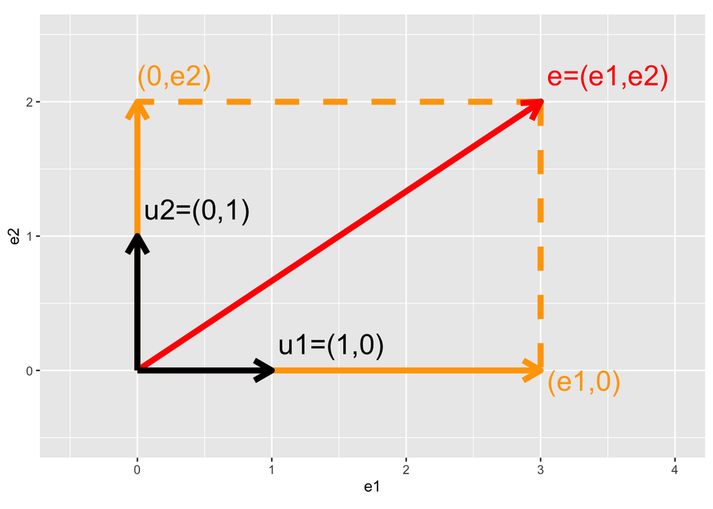

1. Projection of error on x-axis

$$\begin{eqnarray*}
\mathbf{u}_1^T \mathbf{e} &=& \Vert \mathbf{u}_1\Vert_2 \Vert \mathbf{e}_1\Vert_2 \cos <\mathbf{u}_1,\mathbf{e}_1>\\
&=&\left[\begin{array}{cc} 1&0\end{array}\right] \left[\begin{array}{c} e_1\\e_2\end{array}\right]\\ &=& 1\times e_1 + 0 \times e_2 \\
&=& e_1\\
\end{eqnarray*}$$

2. Projection of error on y-axis

$$\begin{eqnarray*}
\mathbf{u}_2^T \mathbf{e} &=& \left[\begin{array}{cc} 0&1\end{array}\right] \left[\begin{array}{c} e_1\\e_2\end{array}\right]\\ &=& 0\times e_1 + 1 \times e_2 \\
&=& e_2
\end{eqnarray*}$$

3. Projection of error on itself

$$\begin{eqnarray*}
\mathbf{e}^T \mathbf{e} &=&\left[\begin{array}{cc} e_1&e_2\end{array}\right] \left[\begin{array}{c} e_1\\e_2\end{array}\right]\\
&=&e_1^2+e_2^2\\
&=&\Vert e \Vert^2_2 \rightarrow \text{ Pythagorean theorem}
\end{eqnarray*}$$

#### Interpretation of least squares as a projection

Fitted values:

$$\begin{array}{lcl}
\hat{\mathbf{Y}} &=& \mathbf{X}\hat{\boldsymbol{\beta}}\\
&=& \mathbf{X} (\mathbf{X}^T\mathbf{X})^{-1}\mathbf{X}^T\mathbf{Y}\\
&=& \mathbf{HY}
\end{array}$$
with $\mathbf{H}$ the projection matrix also referred to as the hat matrix.

```r
X <- model.matrix(~x,data)
X
```

```
  (Intercept) x
1           1 1
2           1 2
3           1 3
attr(,"assign")
[1] 0 1
```

```r
XtX <- t(X)%*%X
XtX
```

```
            (Intercept)  x
(Intercept)           3  6
x                     6 14
```

```r
XtXinv <- solve(t(X)%*%X)
XtXinv
```

```
            (Intercept)    x
(Intercept)    2.333333 -1.0
x             -1.000000  0.5
```

```r
H <- X %*% XtXinv %*% t(X)
H
```

```
           1         2          3
1  0.8333333 0.3333333 -0.1666667
2  0.3333333 0.3333333  0.3333333
3 -0.1666667 0.3333333  0.8333333
```

```r
Y <- data$y
Yhat <- H%*%Y
Yhat
```

```
      [,1]
1 1.166667
2 1.666667
3 2.166667
```

- We can also interpret the fit as the projection of the $n\times 1$ vector $\mathbf{Y}$ on the column space of the matrix $\mathbf{X}$.
- So each column in $\mathbf{X}$ is also an $n\times 1$ vector.
- For the toy example n=3 and p=2. The other picture to linear regression is to consider $X_0$, $X_1$ and $Y$ as vectors in the space of the data $\mathbb{R}^n$, here $\mathbb{R}^3$ because we have three data points. So the column space of X is a plane in the three dimensional space.

$$\hat{\mathbf{Y}} = \mathbf{X} (\mathbf{X}^T\mathbf{X})^{-1} \mathbf{X}^T \mathbf{Y}$$

1. Plane spanned by column space:

```r
originRn <- data.frame(X1=0,X2=0,X3=0)
data$x0 <- 1
dataRn <- data.frame(t(data))

library(plotly)
p1 <- plot_ly(
    originRn,
    x = ~ X1,
    y = ~ X2,
    z= ~ X3, name="origin") |>
  add_markers(type="scatter3d") |>
  layout(
    scene = list(
      aspectmode="cube",
      xaxis = list(range=c(-4,4)), yaxis = list(range=c(-4,4)), zaxis = list(range=c(-4,4))
      )
    )
p1 <- p1 |>
  add_trace(
    x = c(0,1),
    y = c(0,0),
    z = c(0,0),
    mode = "lines",
    line = list(width = 5, color = "grey"),
    type="scatter3d",
    name = "obs1") |>
  add_trace(
    x = c(0,0),
    y = c(0,1),
    z = c(0,0),
    mode = "lines",
    line = list(width = 5, color = "grey"),
    type="scatter3d",
    name = "obs2") |>
  add_trace(
    x = c(0,0),
    y = c(0,0),
    z = c(0,1),
    mode = "lines",
    line = list(width = 5, color = "grey"),
    type="scatter3d",
    name = "obs3") |>
  add_trace(
    x = c(0,1),
    y = c(0,1),
    z = c(0,1),
    mode = "lines",
    line = list(width = 5, color = "black"),
    type="scatter3d",
    name = "X1") |>
    add_trace(
    x = c(0,1),
    y = c(0,2),
    z = c(0,3),
    mode = "lines",
    line = list(width = 5, color = "black"),
    type="scatter3d",
    name = "X2")
p1
```

[interactive chart not shown]

2. Vector of Y:

Actual values of $\mathbf{Y}$:

```r
data$y
```

```
[1] 1 2 2
```

$$\mathbf{Y}=\left[\begin{array}{c}
1 \\
2 \\
2
\end{array}\right]$$

```r
p2 <- p1 |>
  add_trace(
    x = c(0,Y[1]),
    y = c(0,Y[2]),
    z = c(0,Y[3]),
    mode = "lines",
    line = list(width = 5, color = "red"),
    type="scatter3d",
    name = "Y")
p2
```

[interactive chart not shown]

3. Projection of Y onto column space

Actual values of fitted values $\mathbf{\hat{Y}}$:

```r
data$yhat
```

```
[1] 1.166667 1.666667 2.166667
```

$$\mathbf{Y}=\left[\begin{array}{c}
1.1666667 \\
1.6666667 \\
2.1666667
\end{array}\right]$$

```r
p2 <- p2 |>
  add_trace(
    x = c(0,Yhat[1]),
    y = c(0,Yhat[2]),
    z = c(0,Yhat[3]),
    mode = "lines",
    line = list(width = 5, color = "orange"),
    type="scatter3d",
    name="Yhat") |>
    add_trace(
    x = c(Y[1],Yhat[1]),
    y = c(Y[2],Yhat[2]),
    z = c(Y[3],Yhat[3]),
    mode = "lines",
    line = list(width = 5, color = "red", dash="dash"),
    type="scatter3d",
    name="Y -> Yhat"
    )
p2
```

[interactive chart not shown]

$\mathbf{Y}$ is projected in the column space of $\mathbf{X}$! spanned by the columns.

#### How does this projection works?

$$\begin{array}{lcl}
\hat{\mathbf{Y}} &=& \mathbf{X} (\mathbf{X}^T\mathbf{X})^{-1}\mathbf{X}^T\mathbf{Y}\\
&=& \mathbf{X}(\mathbf{X}^T\mathbf{X})^{-1/2}(\mathbf{X}^T\mathbf{X})^{-1/2}\mathbf{X}^T\mathbf{Y}\\
&=& \mathbf{U}\mathbf{U}^T\mathbf{Y}
\end{array}$$

- $\mathbf{U}$ is a new orthonormal basis in $\mathbb{R}^2$, a subspace of $\mathbb{R}^3$
- The space spanned by U and X is the column space of X, e.g. it contains all possible linear combinantions of X. $\mathbf{U}^t\mathbf{Y}$ is the projection of Y on this new orthonormal basis

```r
eigenXtX <- eigen(XtX)
XtXinvSqrt <- eigenXtX$vectors %*%diag(1/eigenXtX$values^.5)%*%t(eigenXtX$vectors)
U <- X %*% XtXinvSqrt
```

- $\mathbf{U}$ orthonormal basis

```r
U
```

```
        [,1]        [,2]
1  0.9116067 -0.04802616
2  0.3881706  0.42738380
3 -0.1352655  0.90279376
```

```r
t(U)%*%U
```

```
             [,1]         [,2]
[1,] 1.000000e+00 2.915205e-16
[2,] 2.915205e-16 1.000000e+00
```

- $\mathbf{UU}^T$ equals projection matrix

```r
U%*%t(U)
```

```
           1         2          3
1  0.8333333 0.3333333 -0.1666667
2  0.3333333 0.3333333  0.3333333
3 -0.1666667 0.3333333  0.8333333
```

```r
H
```

```
           1         2          3
1  0.8333333 0.3333333 -0.1666667
2  0.3333333 0.3333333  0.3333333
3 -0.1666667 0.3333333  0.8333333
```

```r
p3 <- p1 |>
  add_trace(
    x = c(0,U[1,1]),
    y = c(0,U[2,1]),
    z = c(0,U[3,1]),
    mode = "lines",
    line = list(width = 5, color = "blue"),
    type="scatter3d",
    name = "U1") |>
  add_trace(
    x = c(0,U[1,2]),
    y = c(0,U[2,2]),
    z = c(0,U[3,2]),
    mode = "lines",
    line = list(width = 5, color = "blue"),
    type="scatter3d",
    name = "U2")

p3
```

[interactive chart not shown]

- $\mathbf{U}^T\mathbf{Y}$ is the projection of $\mathbf{Y}$ in the space spanned by $\mathbf{U}$.
- Indeed $\mathbf{U}_1^T\mathbf{Y}$

```r
p4 <- p3 |>
  add_trace(
    x = c(0,Y[1]),
    y = c(0,Y[2]),
    z = c(0,Y[3]),
    mode = "lines",
    line = list(width = 5, color = "red"),
    type="scatter3d",
    name = "Y") |>
  add_trace(
    x = c(0,U[1,1]*(U[,1]%*%Y)),
    y = c(0,U[2,1]*(U[,1]%*%Y)),
    z = c(0,U[3,1]*(U[,1]%*%Y)),
    mode = "lines",
    line = list(width = 5, color = "red",dash="dash"),
    type="scatter3d",
    name="Y -> U1") |> add_trace(
    x = c(Y[1],U[1,1]*(U[,1]%*%Y)),
    y = c(Y[2],U[2,1]*(U[,1]%*%Y)),
    z = c(Y[3],U[3,1]*(U[,1]%*%Y)),
    mode = "lines",
    line = list(width = 5, color = "red", dash="dash"),
    type="scatter3d",
    name="Y -> U1")
p4
```

[interactive chart not shown]

- and $\mathbf{U}_2^T\mathbf{Y}$

```r
p5 <- p4 |>
  add_trace(
    x = c(0,U[1,2]*(U[,2]%*%Y)),
    y = c(0,U[2,2]*(U[,2]%*%Y)),
    z = c(0,U[3,2]*(U[,2]%*%Y)),
    mode = "lines",
    line = list(width = 5, color = "red",dash="dash"),
    type="scatter3d",
    name="Y -> U2") |> add_trace(
    x = c(Y[1],U[1,2]*(U[,2]%*%Y)),
    y = c(Y[2],U[2,2]*(U[,2]%*%Y)),
    z = c(Y[3],U[3,2]*(U[,2]%*%Y)),
    mode = "lines",
    line = list(width = 5, color = "red", dash="dash"),
    type="scatter3d",
    name="Y -> U2")
p5
```

[interactive chart not shown]

- $\hat{\mathbf{Y}}$ is the resulting vector that lies in the plane spanned by $\mathbf{U}_1$ and $\mathbf{U}_2$ and thus also in the column space of $\mathbf{X}$.

```r
p6 <- p5 |>
  add_trace(
    x = c(0,Yhat[1]),
    y = c(0,Yhat[2]),
    z = c(0,Yhat[3]),
    mode = "lines",
    line = list(width = 5, color = "orange"),
    type="scatter3d",
    name = "Yhat") |>
  add_trace(
    x = c(Y[1],Yhat[1]),
    y = c(Y[2],Yhat[2]),
    z = c(Y[3],Yhat[3]),
    mode = "lines",
    line = list(width = 5, color = "maroon2"),
    type="scatter3d",
    name = "e") |>
  add_trace(
    x = c(U[1,1]*(U[,1]%*%Y),Yhat[1]),
    y = c(U[2,1]*(U[,1]%*%Y),Yhat[2]),
    z = c(U[3,1]*(U[,1]%*%Y),Yhat[3]),
    mode = "lines",
    line = list(width = 5, color = "orange", dash="dash"),
    type="scatter3d",
    name = "Y -> U")  |>
  add_trace(
    x = c(U[1,2]*(U[,2]%*%Y),Yhat[1]),
    y = c(U[2,2]*(U[,2]%*%Y),Yhat[2]),
    z = c(U[3,2]*(U[,2]%*%Y),Yhat[3]),
    mode = "lines",
    line = list(width = 5, color = "orange", dash="dash"),
    type="scatter3d",
    name = "Y -> U")
p6
```

[interactive chart not shown]

### 5.3.4 Error

Note, that it is also clear from the equation in the derivation of the least squares solution that the residual is orthogonal on the column space:

$$-2 \mathbf{X}^T(\mathbf{Y}-\mathbf{X}\boldsymbol{\beta}) = 0$$

## 5.4 Variance Estimator?

$$\begin{array}{ccl}
\hat{\boldsymbol{\Sigma}}_{\hat{\mathbf{\beta}}}
&=&\text{var}\left[(\mathbf{X}^T\mathbf{X})^{-1}\mathbf{X}^T\mathbf{Y}\right]\\\\
&=&(\mathbf{X}^T\mathbf{X})^{-1}\mathbf{X}^T\text{var}\left[\mathbf{Y}\right]\mathbf{X}(\mathbf{X}^T\mathbf{X})^{-1}\\\\
&=&(\mathbf{X}^T\mathbf{X})^{-1}\mathbf{X}^T(\mathbf{I}\sigma^2)\mathbf{X}(\mathbf{X}^T\mathbf{X})^{-1}
\\\\
&=&(\mathbf{X}^T\mathbf{X})^{-1}\mathbf{X}^T\mathbf{I}\quad\mathbf{X}(\mathbf{X}^T\mathbf{X})^{-1}\sigma^2\\\\
%\hat{\boldmath{\Sigma}}_{\hat{\mathbf{\beta}}}&=&(\mathbf{X}^T\mathbf{X})^{-1}\mathbf{X}^T\var\left[\mathbf{Y}\right](\mathbf{X}^T\mathbf{X})^{-1}\mathbf{X}\\
&=&(\mathbf{X}^T\mathbf{X})^{-1}\mathbf{X}^T\mathbf{X}(\mathbf{X}^T\mathbf{X})^{-1}\sigma^2\\\\
&=&(\mathbf{X}^T\mathbf{X})^{-1}\sigma^2
\end{array}$$

## 5.5 Contrasts

Hypotheses often involve linear combinations of the model parameters!

e.g.

- $H_0: \log_2{FC}_{g3n1-g1n1}= \beta_{g3} + \hat\beta_{g3n1}=0$ $\rightarrow$ “grade3+grade3:node1 = 0”
- Let
  $$\boldsymbol{\beta} = \left[
  \begin{array}{c}
  \beta_{0}\\
  \beta_{g3}\\
  \beta_{n1}\\
  \beta_{g3:n1}
  \end{array}
  \right]$$
- we can write that contrast using a contrast matrix:
  $$\mathbf{L}=\left[\begin{array}{c}0\\1\\0\\1\end{array}\right] \rightarrow \mathbf{L}^T\boldsymbol{\beta}$$
- Then the variance becomes:
  $$\text{var}_{\mathbf{L}^T\boldsymbol{\hat\beta}}= \mathbf{L}^T \boldsymbol{\Sigma}_{\boldsymbol{\hat\beta}}\mathbf{L}$$

# 6 Homework: Adopt the gene analysis on log scale in matrix form!

1. Study the solution of the exercise to understand the analysis in R
2. Calculate
- model parameters and contrasts of interest
- standard errors, standard errors on contrasts
- t-test statistics on the model parameters and contrasts of interest
3. Compare your results with the output of the lm(.) function

## 6.1 Inspiration

Tip: details on the implementation can be found in the book of Faraway (chapter 2). https://people.bath.ac.uk/jjf23/book/

- Design matrix

```r
X <- model.matrix(~grade*node,data=gene)
```

- Transpose of a matrix: use function t(.)

```r
t(X)
```

```
             1 2 3 4 5 6 7 8 9 10 11 12 13 14 15 16 17 18 19 20 21 22 23 24
(Intercept)  1 1 1 1 1 1 1 1 1  1  1  1  1  1  1  1  1  1  1  1  1  1  1  1
grade3       1 1 0 0 0 1 1 0 1  1  0  1  0  0  0  1  0  1  0  1  0  1  1  0
node1        1 1 1 1 0 0 1 1 0  0  0  0  0  0  0  1  1  0  1  1  1  0  1  0
grade3:node1 1 1 0 0 0 0 1 0 0  0  0  0  0  0  0  1  0  0  0  1  0  0  1  0
attr(,"assign")
[1] 0 1 2 3
attr(,"contrasts")
attr(,"contrasts")$grade
[1] "contr.treatment"

attr(,"contrasts")$node
[1] "contr.treatment"
```

- Matrix product %*% operator

```r
t(X)%*%X
```

```
             (Intercept) grade3 node1 grade3:node1
(Intercept)           24     12    12            6
grade3                12     12     6            6
node1                 12      6    12            6
grade3:node1           6      6     6            6
```

- Degrees of freedom of a model?

$$df = n-p$$

```r
summary(lm1)
```

```
Call:
lm(formula = y ~ x, data = data)

Residuals:
      1       2       3
-0.1667  0.3333 -0.1667

Coefficients:
            Estimate Std. Error t value Pr(>|t|)
(Intercept)   0.6667     0.6236   1.069    0.479
x             0.5000     0.2887   1.732    0.333

Residual standard error: 0.4082 on 1 degrees of freedom
Multiple R-squared:   0.75, Adjusted R-squared:    0.5
F-statistic:     3 on 1 and 1 DF,  p-value: 0.3333
```

```r
dfRes <- (nrow(X)-ncol(X))
dfRes
```

```
[1] 20
```

- Variance estimator: MSE

$$\hat \sigma^2 = \frac{\sum\limits_{i=1}^n\epsilon_i^2}{n-p}$$

- Invert matrix: use function solve(.)
- Diagonal elements of a matrix: use function diag(.)

```r
t(X)%*%X
```

```
             (Intercept) grade3 node1 grade3:node1
(Intercept)           24     12    12            6
grade3                12     12     6            6
node1                 12      6    12            6
grade3:node1           6      6     6            6
```

```r
diag(t(X)%*%X)
```

```
 (Intercept)       grade3        node1 grade3:node1
          24           12           12            6
```